# Propagación de Etiquetas en R

Ejemplo semi-supervisado

```r
library(ggplot2)
library(dplyr)
```

# Propagación de Etiquetas en R

## 1. Introducción

En este documento se implementa un método de **aprendizaje semi-supervisado**: solo una pequeña fracción de los datos tiene etiqueta conocida y el resto se trata como no etiquetado. El algoritmo de **Propagación de Etiquetas** aprovecha la geometría de *todos* los puntos (etiquetados y no etiquetados) para difundir información desde los conocidos hacia los desconocidos.

No se entrena un clasificador supervisado clásico (por ejemplo, una frontera global estimada solo con los etiquetados). En su lugar, se construye un **grafo** cuyos nodos son las observaciones y cuyas aristas ponderan la **similitud** entre pares de puntos; las etiquetas iniciales se **propagan** por el grafo hasta estabilizarse. El enfoque es en gran medida **transductivo**: las predicciones se obtienen para los mismos puntos que participaron en la construcción del grafo.

## 2. Generación de datos sintéticos

Se generan dos clases con forma de **dos medias lunas**, útil para ilustrar comportamiento no lineal. La reproducibilidad se fija con `set.seed(123)`.

```r
set.seed(123)

n <- 120
ruido <- 0.08

theta_1 <- runif(n, 0, pi)
theta_2 <- runif(n, 0, pi)

clase_1 <- data.frame(
  x1 = cos(theta_1) + rnorm(n, 0, ruido),
  x2 = sin(theta_1) + rnorm(n, 0, ruido),
  clase_real = "Clase A"
)

clase_2 <- data.frame(
  x1 = 1 - cos(theta_2) + rnorm(n, 0, ruido),
  x2 = -sin(theta_2) + 0.5 + rnorm(n, 0, ruido),
  clase_real = "Clase B"
)

datos <- rbind(clase_1, clase_2)
datos$id <- 1:nrow(datos)
```

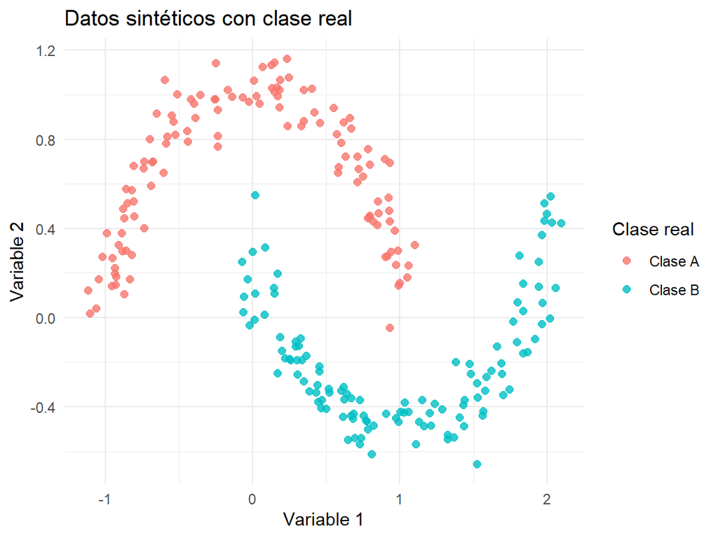

```r
ggplot(datos, aes(x = x1, y = x2, color = clase_real)) +
  geom_point(size = 2, alpha = 0.8) +
  labs(
    title = "Datos sintéticos con clase real",
    x = "Variable 1",
    y = "Variable 2",
    color = "Clase real"
  ) +
  theme_minimal()
```

## 3. Selección de datos etiquetados y no etiquetados

Se eligen **tres** observaciones etiquetadas por clase; el resto queda sin etiqueta observada. La columna `clase_real` se conserva únicamente para evaluación.

```r
set.seed(123)

etiquetados <- datos %>%
  group_by(clase_real) %>%
  slice_sample(n = 3) %>%
  ungroup()

datos$clase_observada <- NA
datos$clase_observada[datos$id %in% etiquetados$id] <- datos$clase_real[datos$id %in% etiquetados$id]

datos$tipo <- ifelse(is.na(datos$clase_observada), "No etiquetado", "Etiquetado")
```

```r
table(datos$tipo)
```

```
##
##    Etiquetado No etiquetado
##             6           234
```

```r
table(datos$clase_observada, useNA = "ifany")
```

```
##
## Clase A Clase B    <NA>
##       3       3     234
```

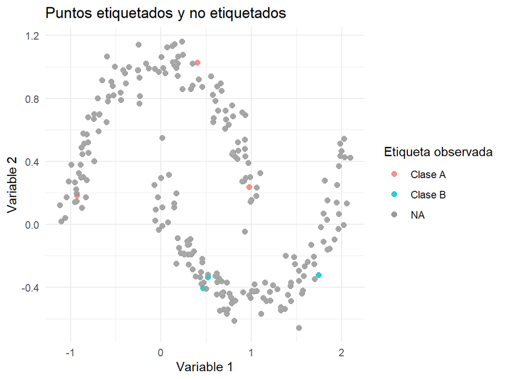

```r
ggplot(datos, aes(x = x1, y = x2)) +
  geom_point(aes(color = clase_observada), size = 2, alpha = 0.8) +
  geom_point(
    data = datos %>% filter(tipo == "No etiquetado"),
    color = "gray70",
    size = 1.8,
    alpha = 0.5
  ) +
  labs(
    title = "Puntos etiquetados y no etiquetados",
    x = "Variable 1",
    y = "Variable 2",
    color = "Etiqueta observada"
  ) +
  theme_minimal()
```

## 4. Construcción del grafo de similitud

La matriz de similitud **W** usa un núcleo gaussiano sobre la distancia euclídea al cuadrado:

$$W_{ij} = \exp\left(-\frac{d_{ij}^2}{2\sigma^2}\right)$$

donde $d_{ij}$ es la distancia entre los puntos $i$ y $j$, y $\sigma$ controla qué tan **local** es la similitud: $\sigma$ muy pequeño produce un grafo muy disperso; $\sigma$ muy grande acerca demasiado los pesos entre nodos lejanos.

```r
X <- as.matrix(datos[, c("x1", "x2")])

distancias <- as.matrix(dist(X))
distancias_2 <- distancias^2

sigma <- median(distancias[distancias > 0])

W <- exp(-distancias_2 / (2 * sigma^2))
diag(W) <- 0
```

```r
dim(W)
```

```
## [1] 240 240
```

```r
summary(diag(W))
```

```
##    Min. 1st Qu.  Median    Mean 3rd Qu.    Max.
##       0       0       0       0       0       0
```

## 5. Implementación del algoritmo de Propagación de Etiquetas

Se construye la matriz **Y** de etiquetas iniciales (indicadores one-hot por fila). Los nodos no etiquetados tienen filas de ceros. Se normaliza el grafo con la matriz simétrica **S** = $D^{-1/2} W D^{-1/2}$, donde **D** es diagonal con los grados (suma de pesos por fila de **W**).

La iteración sigue la forma de **consistencia local y global**:

$$F^{(t+1)} = \alpha S F^{(t)} + (1-\alpha) Y$$

con $\alpha \in (0,1)$: un $\alpha$ alto da más peso a la estructura del grafo; $(1-\alpha)Y$ ancla las etiquetas conocidas.

```r
clases <- sort(unique(datos$clase_real))
labeled_idx <- which(!is.na(datos$clase_observada))

Y <- matrix(0, nrow = nrow(datos), ncol = length(clases))
colnames(Y) <- clases

Y[cbind(labeled_idx, match(datos$clase_observada[labeled_idx], clases))] <- 1
```

```r
grados <- rowSums(W)
D_inv_sqrt <- diag(1 / sqrt(grados + 1e-12))

S <- D_inv_sqrt %*% W %*% D_inv_sqrt
```

```r
alpha <- 0.95
max_iter <- 1000
tol <- 1e-6

F <- Y

for (iter in 1:max_iter) {
  F_anterior <- F

  F <- alpha * S %*% F + (1 - alpha) * Y

  cambio <- max(abs(F - F_anterior))

  if (cambio < tol) {
    break
  }
}

iter
```

```
## [1] 11
```

```r
cambio
```

```
## [1] 7.136491e-07
```

```r
pred_idx <- max.col(F, ties.method = "first")
datos$clase_predicha <- clases[pred_idx]

datos$confianza <- apply(F, 1, max) / pmax(rowSums(F), 1e-12)
```

## 6. Visualización de resultados

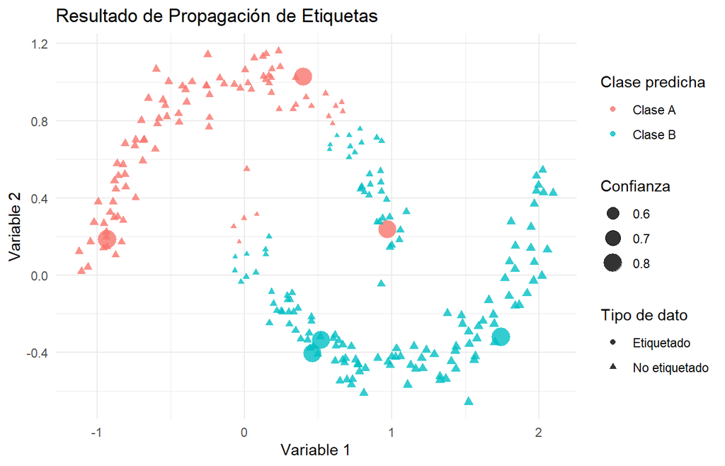

```r
ggplot(datos, aes(x = x1, y = x2, color = clase_predicha)) +
  geom_point(aes(size = confianza, shape = tipo), alpha = 0.8) +
  labs(
    title = "Resultado de Propagación de Etiquetas",
    x = "Variable 1",
    y = "Variable 2",
    color = "Clase predicha",
    shape = "Tipo de dato",
    size = "Confianza"
  ) +
  theme_minimal()
```

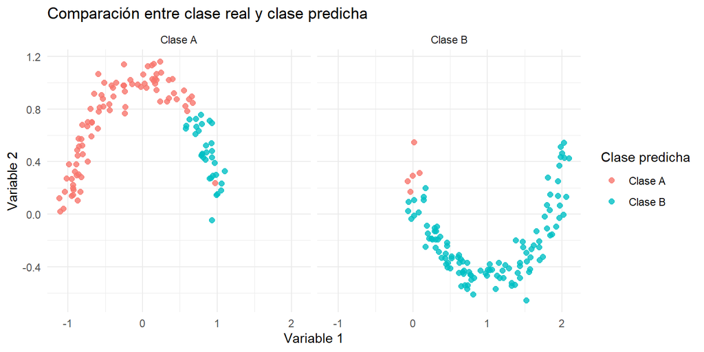

```r
ggplot(datos, aes(x = x1, y = x2)) +
  geom_point(aes(color = clase_predicha), size = 2, alpha = 0.8) +
  facet_wrap(~ clase_real) +
  labs(
    title = "Comparación entre clase real y clase predicha",
    x = "Variable 1",
    y = "Variable 2",
    color = "Clase predicha"
  ) +
  theme_minimal()
```

## 7. Evaluación sencilla

La métrica principal es el acierto en los puntos **no etiquetados**, que son los que el método debía inferir.

```r
unlabeled_idx <- which(is.na(datos$clase_observada))

accuracy_unlabeled <- mean(datos$clase_predicha[unlabeled_idx] == datos$clase_real[unlabeled_idx])
accuracy_total <- mean(datos$clase_predicha == datos$clase_real)

accuracy_unlabeled
```

```
## [1] 0.8418803
```

```r
accuracy_total
```

```
## [1] 0.8458333
```

```r
table(
  Real = datos$clase_real[unlabeled_idx],
  Predicha = datos$clase_predicha[unlabeled_idx]
)
```

```
##          Predicha
## Real      Clase A Clase B
##   Clase A      85      32
##   Clase B       5     112
```

## 8. Interpretación

1. **Puntos etiquetados**: se tomaron tres observaciones al azar por clase (`slice_sample(n = 3)` dentro de cada `clase_real`), fijando la semilla para reproducibilidad.
2. **Grafo**: se calculó la distancia euclídea entre todos los pares de puntos en $(x_1, x_2)$ y se transformó en pesos gaussianos; la diagonal de **W** es cero (sin bucles).
3. **Matriz W**: similitud pareada; valores altos indican vecinos cercanos en el sentido del núcleo gaussiano.
4. **Matriz S**: versión normalizada simétrica del grafo, que equilibra el peso de nodos con distinto grado antes de difundir etiquetas.
5. **Actualización iterativa**: en cada paso, **F** mezcla la difusión por **S** con el anclaje **Y**; al converger, **F** refleja a la vez suavidad en el grafo y respeto a las etiquetas fijas.
6. **Puntos no etiquetados**: reciben clase porque sus filas en **F** se van alineando con vecinos similares en el grafo, arrastrados por la propagación desde los sembrados etiquetados.
7. **Rendimiento**: el `accuracy_unlabeled` cuantifica qué tan bien se recuperó la `clase_real` en los no observados (ver chunk anterior).
8. **Menos etiquetados**: con `slice_sample(n = 1)` el anclaje es más débil y el error suele subir si los únicos sembrados no representan bien cada región de la media luna.
9. **Sigma**: muy pequeño fragmenta el grafo (poca difusión entre regiones); muy grande une demasiado y puede mezclar ambas lunas en el espectro de **W**.
10. **Alpha**: valores bajas acercan **F** a **Y** (poca suavidad); valores altas acentúan la consistencia con vecinos pero pueden amplificar errores si el grafo conecta mal clases distintas.

En conjunto, el método rinde bien cuando **la similitud en el grafo refleja la verdadera estructura de clases** (vecinos del mismo semicírculo comparten etiqueta).

## 9. Conclusiones

- La Propagación de Etiquetas incorpora los datos **no etiquetados** en el propio mecanismo de inferencia, no solo como puntos futuros a clasificar con un modelo ajustado solo con etiquetados.
- Se apoya en la hipótesis de **suavidad**: observaciones similares deberían compartir etiqueta en el grafo.
- La elección de **W** (y por tanto de $\sigma$) es central: define quién influye a quién.
- Con **pocos** puntos etiquetados puede clasificarse gran parte del conjunto si la forma de las clases es clara y el grafo la respeta.
- Si el grafo **conecta en exceso** regiones de distinta clase, la difusión mezcla etiquetas y el error aumenta.

## Experimentos adicionales

Tres variaciones rápidas sobre la misma semilla y datos base (se reejecuta el flujo desde la selección de etiquetados o desde **W** según corresponda).

### Experimento 1: Cantidad de puntos etiquetados

```r
run_lp <- function(k_etiq) {
  set.seed(123)
  etiquetados_k <- datos %>%
    group_by(clase_real) %>%
    slice_sample(n = k_etiq) %>%
    ungroup()

  clase_obs <- rep(NA_character_, nrow(datos))
  clase_obs[datos$id %in% etiquetados_k$id] <-
    datos$clase_real[datos$id %in% etiquetados_k$id]

  labeled <- which(!is.na(clase_obs))
  Yk <- matrix(0, nrow = nrow(datos), ncol = length(clases))
  colnames(Yk) <- clases
  Yk[cbind(labeled, match(clase_obs[labeled], clases))] <- 1

  Fk <- Yk
  for (it in 1:max_iter) {
    Fprev <- Fk
    Fk <- alpha * S %*% Fk + (1 - alpha) * Yk
    if (max(abs(Fk - Fprev)) < tol) break
  }
  pred_k <- clases[max.col(Fk, ties.method = "first")]
  unlab <- which(is.na(clase_obs))
  mean(pred_k[unlab] == datos$clase_real[unlab])
}

data.frame(
  k_por_clase = c(1, 3, 5),
  accuracy_no_etiq = c(run_lp(1), run_lp(3), run_lp(5))
)
```

```
##   k_por_clase accuracy_no_etiq
## 1           1        0.5000000
## 2           3        0.8418803
## 3           5        0.8260870
```

### Experimento 2: Escala de sigma

```r
sigma_base <- median(distancias[distancias > 0])

run_lp_sigma <- function(sigma_mult) {
  sig <- sigma_base * sigma_mult
  Ws <- exp(-distancias_2 / (2 * sig^2))
  diag(Ws) <- 0
  gs <- rowSums(Ws)
  Ds <- diag(1 / sqrt(gs + 1e-12))
  Ss <- Ds %*% Ws %*% Ds

  Fk <- Y
  for (it in 1:max_iter) {
    Fprev <- Fk
    Fk <- alpha * Ss %*% Fk + (1 - alpha) * Y
    if (max(abs(Fk - Fprev)) < tol) break
  }
  pred_k <- clases[max.col(Fk, ties.method = "first")]
  mean(pred_k[unlabeled_idx] == datos$clase_real[unlabeled_idx])
}

data.frame(
  sigma_factor = c(0.5, 1, 2),
  accuracy_no_etiq = c(
    run_lp_sigma(0.5),
    run_lp_sigma(1),
    run_lp_sigma(2)
  )
)
```

```
##   sigma_factor accuracy_no_etiq
## 1          0.5        0.8846154
## 2          1.0        0.8418803
## 3          2.0        0.8418803
```

### Experimento 3: Valor de alpha

```r
run_lp_alpha <- function(al) {
  Fa <- Y
  for (it in 1:max_iter) {
    Fprev <- Fa
    Fa <- al * S %*% Fa + (1 - al) * Y
    if (max(abs(Fa - Fprev)) < tol) break
  }
  pred_a <- clases[max.col(Fa, ties.method = "first")]
  mean(pred_a[unlabeled_idx] == datos$clase_real[unlabeled_idx])
}

data.frame(
  alpha = c(0.50, 0.80, 0.95, 0.99),
  accuracy_no_etiq = c(
    run_lp_alpha(0.50),
    run_lp_alpha(0.80),
    run_lp_alpha(0.95),
    run_lp_alpha(0.99)
  )
)
```

```
##   alpha accuracy_no_etiq
## 1  0.50        0.8547009
## 2  0.80        0.8504274
## 3  0.95        0.8418803
## 4  0.99        0.5000000
```

## Validaciones mínimas

```r
sum(is.na(datos$clase_predicha))
```

```
## [1] 0
```

```r
dim(W)
```

```
## [1] 240 240
```

```r
dim(S)
```

```
## [1] 240 240
```

```r
dim(Y)
```

```
## [1] 240   2
```

```r
dim(F)
```

```
## [1] 240   2
```

```r
iter < max_iter
```

```
## [1] TRUE
```

## Referencias

- Zhu, X., & Ghahramani, Z. (2003). *Learning from Labeled and Unlabeled Data with Label Propagation*.
- Zhou, D., Bousquet, O., Lal, T. N., Weston, J., & Schölkopf, B. (2004). *Learning with Local and Global Consistency*. Advances in Neural Information Processing Systems, 16.
- van Engelen, J. E., & Hoos, H. H. (2020). *A survey on semi-supervised learning*. Machine Learning, 109(2), 373–440. https://doi.org/10.1007/s10994-019-05855-6